# BCB 520 Assignment 3 - Task Abstraction

Author

Heidi Sellmann

## Import Data

```r
library(readxl)
Cytokine_summary <- read_excel("Cytokine_summary.xlsx")
View(Cytokine_summary)
knitr::kable(Cytokine_summary)
```

| Pig | IL1B_Jej_pg_mL | IL1B_Ile_pg_mL | IL1B_Col_pg_mL | TNFA_Jej_pg_mL | TNFA_Ile_pg_mL | TNFA_Col_pg_mL | IL8_Jej_pg_mL | IL8_Ile_pg_mL | IL8_Col_pg_mL |
| --- | --- | --- | --- | --- | --- | --- | --- | --- | --- |
| P1 | 158.107 | 258.529 | 18.902 | 10.084 | 191.685 | 67.410 | 2717.095 | 3244.064 | 48.389 |
| C1 | 304.570 | 300.510 | 173.388 | 5.293 | 148.321 | 53.500 | 1807.191 | 2747.520 | 521.019 |
| HM1 | 126.749 | 92.684 | 80.020 | 0.000 | 163.895 | 0.000 | 2163.072 | 1842.670 | 93.936 |
| HM2 | 90.214 | 72.580 | 75.545 | 0.000 | 130.676 | 0.000 | 3434.170 | 3433.543 | 194.084 |
| HM3 | 114.224 | 79.751 | 239.901 | 0.000 | 0.000 | 28.050 | 1649.797 | 1678.069 | 334.678 |
| HM4 | 132.318 | 107.964 | 155.655 | 3.612 | 5.265 | 18.105 | 3390.124 | 3088.125 | 373.427 |
| HM5 | 68.657 | 49.695 | 12.045 | 0.000 | 112.351 | 0.000 | 3148.633 | 3153.588 | 172.843 |
| HM6 | 112.428 | 57.860 | 52.582 | 0.000 | 0.000 | 0.000 | 3088.206 | 4084.593 | 183.157 |
| P2 | 194.675 | 145.165 | 63.666 | 12.729 | 18.287 | 89.610 | 2474.794 | 2692.826 | 880.425 |
| C2 | 401.575 | 564.465 | 305.068 | 42.442 | 17.261 | 84.509 | 1635.162 | 1030.576 | 255.938 |
| IF1 | 174.037 | 130.035 | 38.956 | 0.000 | 105.243 | 3.978 | 2013.397 | 1678.351 | 49.232 |
| IF2 | 126.663 | 115.666 | 76.857 | 0.000 | 63.294 | 4.975 | 3399.788 | 1727.786 | 116.573 |
| IF3 | 141.120 | 53.064 | 182.891 | 4.574 | 0.000 | 12.948 | 3766.222 | 504.454 | 38.554 |
| IF4 | 132.275 | 78.283 | 18.266 | 9.628 | 154.257 | 0.000 | 3705.406 | 2293.403 | 222.193 |
| IF5 | 111.800 | 91.316 | 82.741 | 0.000 | 223.890 | 4.293 | 3228.713 | 2499.064 | 103.378 |
| IF6 | 159.411 | 120.352 | 31.099 | 0.000 | 5.171 | 0.000 | 2001.489 | 2659.008 | 173.974 |

## Load Libraries

```r
library(tidyverse)
library(ggplot2)
```

Now that I have the necessary data and packages, I want to make a box blot distribution of my various cytokines per pig feeding group - HM, IF, P, and C. Barrie helped me with this!

## Organize the Data

Here we add another column into Cytokine_summary via R

```r
Cytokine_summary <- Cytokine_summary %>%
  mutate(Diet = str_sub(Pig, 1, 1))
```

## What does each diet look like?

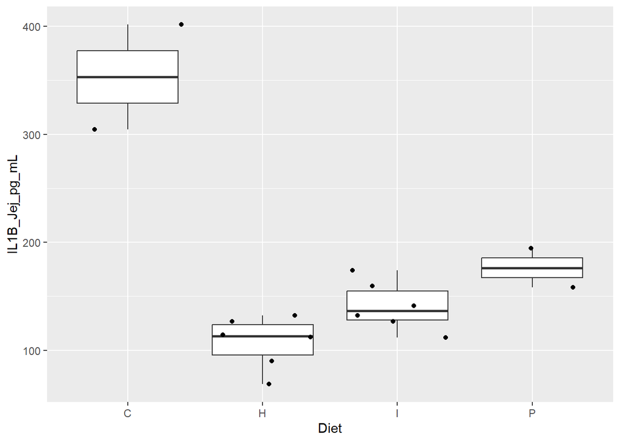

```r
ggplot(Cytokine_summary, aes(x = Diet, y = IL1B_Jej_pg_mL)) +
  geom_boxplot() +
  geom_jitter()
```

### Legend:

C = Farm Control

H = HM

I = IF

P = Lab Control

Now I could create individual ones of these for each column… but we are going to try to work smarter, not harder, and create a new data frame to get all these types of plots into 1 figure.

## Creating 9 plots in 1 figure

First we break up the columns 2-10 to their cytokine and their region.

```r
Cytokine_long <- Cytokine_summary %>%
  pivot_longer(cols = 2:10, names_to ="Reg_Cyt",
 values_to = "Expression") %>%
  separate(Reg_Cyt, into = c("Cytokine", "Region"), sep = "_", remove = FALSE)
```

Now to put that into a boxplot with jitter overlay. We facet_wrapped in order to make subplots from 1 plot (slice it up for the viewers).

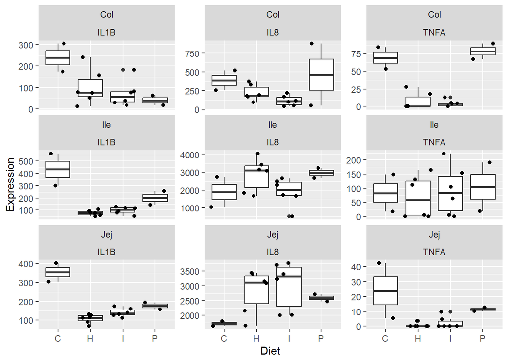

```r
ggplot(Cytokine_long, aes(x = Diet, y = Expression)) +
  geom_boxplot() +
  geom_jitter() +
  facet_wrap(Region ~ Cytokine, scales = "free_y")
```

Great! Now we can move forward looking into normality assumptions and deeper comparisons between particular feeding groups. Perhaps we can use the different regions of the GI tract as blocking factors… More to come!

Thoughts to address: Get rid of error output? Add colors? Pick up with Result project! Also, get it so HM and IF?